# Classify major localisation

Tom Smith

Cambridge Centre for Proteomics

19 November, 2021

Abstract

Here we classify proteins/peptides according to their marker profiles in the unenriched/unmodified LOPIT, using SVM

```r
library(camprotR)
library(tidyverse)
library(MSnbase)
library(pRoloc)
library(biomaRt)
```

```r
pep_classifications <- readRDS('../results/pep_classifications.rds')
```

```r
table(fData(pep_classifications)$filtered_ptm)
```

```
         Glutaryl Glutaryl;Glutaryl  Glutaryl;Malonyl Glutaryl;Succinyl           Malonyl  Malonyl;Succinyl          Succinyl Succinyl;Glutaryl
                7                 1                 1                 4                 3                 3              5955                 1
Succinyl;Succinyl
                4
```

```r
pep_classifications %>%
  fData() %>%
  filter(filtered_ptm %in% c('Succinyl', NA), svm_filtered_ind_thresh!='unknown') %>%
  group_by(filtered_ptm, svm_filtered_ind_thresh) %>%
  tally()
```

| filtered_ptm | svm_filtered_ind_thresh | n |
| --- | --- | --- |
| Succinyl | Cytosol | 484 |
| Succinyl | ER | 355 |
| Succinyl | Golgi | 13 |
| Succinyl | Lysosome | 10 |
| Succinyl | Mitochondria | 172 |
| Succinyl | Nucleus | 492 |
| Succinyl | Peroxisome | 9 |
| Succinyl | PM | 30 |
| Succinyl | Proteasome | 74 |
| Succinyl | Ribosome | 411 |

[output cut: 10 more lines]

```r
pep_classifications %>%
  fData() %>%
  filter(filtered_ptm %in% c('Succinyl', NA), svm_filtered_ind_thresh!='unknown') %>%
  dplyr::select(filtered_ptm, Master.Protein.Accessions, svm_filtered_ind_thresh) %>%
  unique() %>%
  group_by(filtered_ptm, svm_filtered_ind_thresh) %>%
  tally()
```

| filtered_ptm | svm_filtered_ind_thresh | n |
| --- | --- | --- |
| Succinyl | Cytosol | 186 |
| Succinyl | ER | 83 |
| Succinyl | Golgi | 11 |
| Succinyl | Lysosome | 7 |
| Succinyl | Mitochondria | 104 |
| Succinyl | Nucleus | 248 |
| Succinyl | Peroxisome | 4 |
| Succinyl | PM | 27 |
| Succinyl | Proteasome | 37 |
| Succinyl | Ribosome | 106 |

[output cut: 10 more lines]

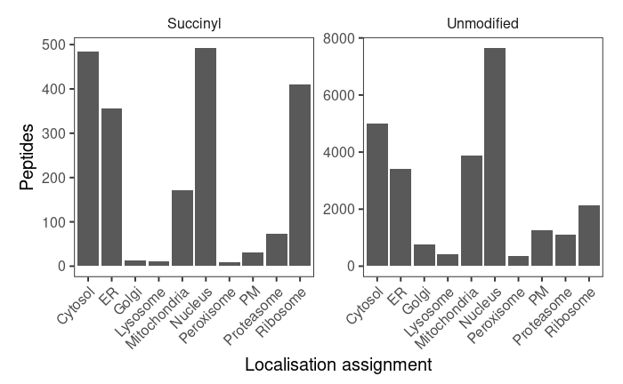

```r
p <- pep_classifications %>%
  fData() %>%
  filter(filtered_ptm %in% c('Succinyl', NA), svm_filtered_ind_thresh!='unknown') %>%
  group_by(filtered_ptm, svm_filtered_ind_thresh) %>%
  tally() %>%
  mutate(filtered_ptm=ifelse(is.na(filtered_ptm), 'Unmodified', filtered_ptm)) %>%
  ggplot(aes(svm_filtered_ind_thresh, n)) +
  geom_bar(stat='identity') +
  facet_wrap(~filtered_ptm, scales='free') +
  theme_camprot(base_size=15, base_family='sans') +
  theme(axis.text.x=element_text(angle=45, vjust=1, hjust=1),
        strip.background=element_blank()) +
  xlab('Localisation assignment') +
  ylab('Peptides')

print(p)
ggsave('../figures/classification_counts.png')
ggsave('../figures/classification_counts.pdf')
```

Finally, let’s look at the enriched GO terms for the succinylated nuclear proteins. As part of this, we will consider the potential biasing factor of protein abundance. Note that the bias (if present) would be technical (easier to detect high abundance), even if more abundant proteins are more likely to have a least one succinylated copy, since the proportion succinylated should not be dependent on abundance, so it still comes down to a difference in the ability to detect low vs high frequency events. We will use PaxDB for this, specifically the Geiger et al U-2 OS data.

```r
u2os_abundances <- read.table('../shared_files/9606-iBAQ_U2OS_Geiger_2012_uniprot.txt')
colnames(u2os_abundances) <- c('internal_id', 'string_id', 'abundance')

u2os_abundances <- u2os_abundances %>%
  separate(string_id, into=c(NA, 'ensembl_peptide_id'))
```

```r
ensembl <- biomaRt::useEnsembl(biomart="ensembl", dataset="hsapiens_gene_ensembl")
peptide2uniprot <- getBM(attributes=c('ensembl_peptide_id', 'uniprotswissprot'),
                         mart = ensembl,
                         filters = 'ensembl_peptide_id',
                         values=u2os_abundances$ensembl_peptide_id)

peptide2uniprot <- peptide2uniprot %>%
  filter(ensembl_peptide_id!='', uniprotswissprot!='')

duplicated_pep_id <- names(table(peptide2uniprot$ensembl_peptide_id))[
  table(peptide2uniprot$ensembl_peptide_id)>1]

duplicated_uniprot_id <- names(table(peptide2uniprot$uniprotswissprot))[
  table(peptide2uniprot$uniprotswissprot)>1]

print(dim(peptide2uniprot))
```

```
[1] 9320    2
```

```r
peptide2uniprot <- peptide2uniprot %>%
  filter(!ensembl_peptide_id %in% duplicated_pep_id,
         !uniprotswissprot %in% duplicated_uniprot_id)

print(dim(peptide2uniprot))
```

```
[1] 9274    2
```

```r
u2os_abundances_uniprot <- merge(u2os_abundances, peptide2uniprot, by='ensembl_peptide_id')
```

```r
x <- pep_classifications %>%
  fData() %>%
  filter(is.na(filtered_ptm))

x %>% dplyr::select(Master.Protein.Accessions) %>%
  unique()
```

|  | Master.Protein.Accessions |
| --- | --- |
| AAAAAAAAAAAAAAAGAGAGAK | P55011 |
| AAAAAAAAAVSR | Q96JP5 |
| AAAAAAALQAK | P36578 |
| AAAAADLANR | O76031 |
| AAAAAGGAAAAAAR | O15265 |
| AAAAALSQQQSLQER | Q8WUQ7 |
| AAAAASAAGPGGLVAGK | A6NIH7 |
| AAAAATVVPPMVGGPPFVGPVGFGPGDR | Q9BTD8 |
| AAAAAWEEPSSGNGTAR | Q9P258 |
| AAAACLDK | Q9H3U1 |

[output cut: 990 more lines]

```r
nuc_abundances <- pep_classifications%>%
  fData() %>%
  filter(svm_filtered_single_threshold=='Nucleus') %>%
  dplyr::select(Master.Protein.Accessions) %>%
  unique() %>%
  merge(u2os_abundances_uniprot, by.x='Master.Protein.Accessions', by.y='uniprotswissprot') %>%
  mutate(binned_abundance=Hmisc::cut2(abundance, g=10))

table(nuc_abundances$binned_abundance)
```

```
[  0.0, 54.7) [ 54.7, 98.5) [ 98.5,135.0) [135.0,147.0) [147.0,155.0) [155.0,163.0) [163.0,171.0) [171.0,182.0) [182.0,198.0) [198.0,475.0]
          160           159           160           161           158           161           161           169           153           152
```

```r
nuc_suc_tally_by_abundance <- pep_classifications %>%
  fData() %>%
  filter(filtered_ptm == 'Succinyl',
         svm_filtered_ind_thresh=='Nucleus') %>%
  dplyr::select(Master.Protein.Accessions, filtered_ptm) %>%
  unique() %>%
  merge(nuc_abundances, by='Master.Protein.Accessions', all.y=TRUE) %>%
  group_by(binned_abundance, suc=filtered_ptm=='Succinyl') %>%
  tally()
```

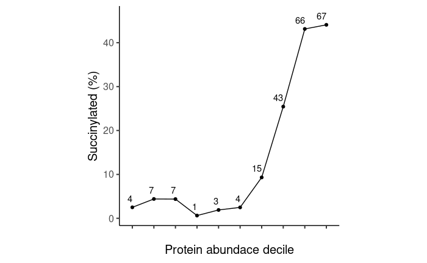

```r
library(ggrepel)

p <- nuc_suc_tally_by_abundance %>%
  pivot_wider(names_from='suc', values_from='n') %>%
  mutate(suc=ifelse(is.na(`TRUE`), 0, `TRUE`)) %>%
  mutate(fraction=100*suc/(suc+`NA`)) %>%
  ggplot(aes(binned_abundance, fraction)) +
  geom_point() +
  geom_text(aes(label=suc, hjust=1, y=fraction+2)) +
  geom_line(group=1) +
  theme_camprot(border=FALSE, base_size=15, base_family='sans') +
  scale_x_discrete(labels=1:10) +
  theme(axis.text.x=element_blank()) +
  xlab('\nProtein abundace decile') +
  ylab('Succinylated (%)')

print(p)
ggsave('../figures/nuclear_succ_proteins_abundance.png')
ggsave('../figures/nuclear_succ_proteins_abundance.pdf')
```

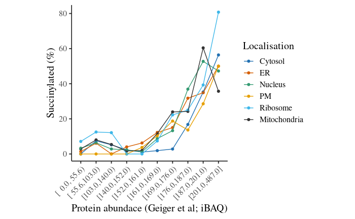

```r
all_abundances <- pep_classifications %>%
  fData() %>%
  filter(svm_filtered_single_threshold!='unknown') %>%
  dplyr::select(svm_filtered_ind_thresh, Master.Protein.Accessions) %>%
  unique() %>%
  merge(u2os_abundances_uniprot, by.x='Master.Protein.Accessions', by.y='uniprotswissprot') %>%
  mutate(binned_abundance=Hmisc::cut2(abundance, g=10))

all_suc_tally_by_abundance <- pep_classifications %>%
  fData() %>%
  filter(filtered_ptm == 'Succinyl',
         svm_filtered_ind_thresh!='unknown') %>%
  dplyr::select(Master.Protein.Accessions, filtered_ptm, svm_filtered_ind_thresh) %>%
  unique() %>%
  merge(all_abundances, by=c('svm_filtered_ind_thresh', 'Master.Protein.Accessions'), all.y=TRUE) %>%
  group_by(svm_filtered_ind_thresh, binned_abundance, suc=filtered_ptm=='Succinyl') %>%
  tally()

n_proteins_per_loc <- all_suc_tally_by_abundance %>%
  group_by(svm_filtered_ind_thresh) %>%
  summarise(n=sum(n))

keep_loc <- n_proteins_per_loc %>% filter(n>200) %>%
  pull(svm_filtered_ind_thresh) %>%
  setdiff(c('unknown', 'Proteasome'))

p <- all_suc_tally_by_abundance %>%
  filter(svm_filtered_ind_thresh %in% keep_loc) %>%
  mutate(svm_filtered_ind_thresh=factor(
    svm_filtered_ind_thresh,
    levels=c(setdiff(keep_loc, 'Mitochondria'), 'Mitochondria'))) %>%
  pivot_wider(names_from='suc', values_from='n') %>%
  mutate(suc=ifelse(is.na(`TRUE`), 0, `TRUE`)) %>%
  mutate(fraction=100*suc/(suc+`NA`)) %>%
  ggplot(aes(binned_abundance, fraction,
             colour=svm_filtered_ind_thresh,
             group=svm_filtered_ind_thresh)) +
  geom_point() +
  geom_line() +
  theme_camprot(border=FALSE, base_size=15) +
  theme(axis.text.x=element_text(angle=45, vjust=1, hjust=1)) +
  xlab('Protein abundace (Geiger et al; iBAQ)') +
  ylab('Succinylated (%)') +
  scale_colour_manual(values=c(get_cat_palette(length(keep_loc)-1), 'grey20'),
                      name='Localisation')

print(p)
```

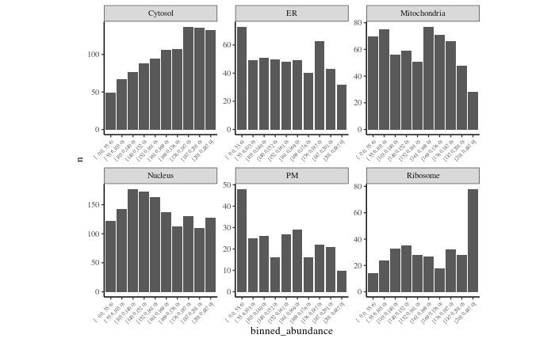

```r
all_suc_tally_by_abundance %>%
  filter(svm_filtered_ind_thresh %in% keep_loc) %>%
  group_by(svm_filtered_ind_thresh, binned_abundance) %>%
  summarise(n=sum(n)) %>%
  ggplot(aes(binned_abundance, n)) +
  geom_bar(stat='identity') +
  facet_wrap(~svm_filtered_ind_thresh, scales='free') +
  theme_camprot(border=FALSE, base_size = 10) +
  theme(axis.text.x=element_text(angle=45, vjust=1, hjust=1, size=5))
```

```r
NA
```

OK, so as expected, clear relationship between proteins abundance and proportion for which we detect succinylated peptides, with ~40% of the most abundant decile having observed succinylated peptides. Strangely though, there are quite succinylated proteins from the lowest 3 deciles too. Regardless, there’s a strong relationship that we should take into account for the GO enrichment. It’s not quite monotonic but close enough to use goseq out of the box

```r
library(goseq)
go_human <- readRDS('../shared_files/h_sapiens_go_full.rds')
```

```r
nuc_suc <- pep_classifications %>%
  fData() %>%
  filter(filtered_ptm == 'Succinyl',
         svm_filtered_single_threshold=='Nucleus') %>%
  pull(Master.Protein.Accessions)

for_go_seq <- nuc_abundances %>% mutate(succinylated=Master.Protein.Accessions %in% nuc_suc)

is_suc <- for_go_seq$succinylated
names(is_suc) <- for_go_seq$Master.Protein.Accessions
table(for_go_seq$succinylated)
```

```
FALSE  TRUE
 1350   244
```

```
initial point very close to some inequality constraintscollapsing to unique 'x' values
```

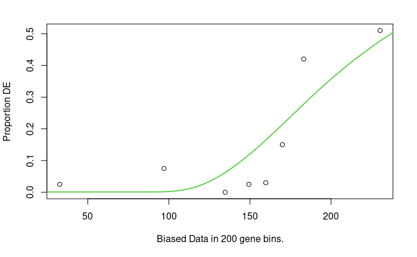

```r
bias <- for_go_seq$abundance
names(bias) <- for_go_seq$Master.Protein.Accessions

pwf <- goseq::nullp(is_suc, bias.data=bias)
```

OK, so goseq::nullp doesn’t fit the relationship quite right. Below, we allow for more knots to improve the fit

```
initial point very close to some inequality constraintscollapsing to unique 'x' values
```

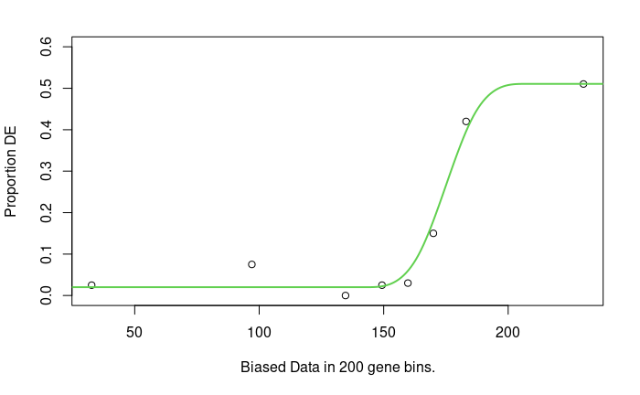

```r
my_nullp <- function (DEgenes, genome, id, bias.data = NULL, plot.fit = TRUE,
                      nknots=6) # default value in goseq::nullp
{
    if (!is.null(bias.data) & length(bias.data) != length(DEgenes)) {
        stop("bias.data vector must have the same length as DEgenes vector!")
    }
    bias.data = unfactor(bias.data)
    DEgenes = unfactor(DEgenes)
    if (is.null(bias.data)) {
        bias.data = getlength(names(DEgenes), genome, id)
    }
    pwf = rep(NA, length(DEgenes))
    w = !is.na(bias.data)
    pwf[w] = goseq::makespline(bias.data[w], DEgenes[w], nKnots = nknots)
    out = data.frame(DEgenes = DEgenes, bias.data = bias.data,
        pwf = pwf, stringsAsFactors = FALSE)
    rownames(out) = names(DEgenes)
    if (plot.fit) {
        plotPWF(out, ylim=c(0, 0.6))
    }
    out
}

pwf_more_knots <- my_nullp(is_suc, bias.data=bias, nknots=19)
```

```r
go_enriched_finalised <- camprotR::get_enriched_go(pwf_more_knots, gene2cat=go_human)
```

```
Number of DE genes input: 244
Using manually entered categories.
For 13 genes, we could not find any categories. These genes will be excluded.
To force their use, please run with use_genes_without_cat=TRUE (see documentation).
This was the default behavior for version 1.15.1 and earlier.
Calculating the p-values...
```

```r
go_enriched_finalised <- go_enriched_finalised %>%
  filter(over_represented_adj_pval<0.1) %>%
  camprotR::remove_redundant_go() %>%
  camprotR::estimate_go_overrep(pwf_more_knots, go_human)
```

```
Warning: the following GO terms failed to match to a primary ontology in GO.db and were removed: GO:0030529
```

```r
print(go_enriched_finalised)
```

| category | over_represented_pvalue | under_represented_pvalue | numDEInCat | numInCat | term | ontology | over_represented_adj_pval | under_represented_adj_pval | term_short | adj_overrep |
| --- | --- | --- | --- | --- | --- | --- | --- | --- | --- | --- |
| GO:1990904 | 1.960705e-08 | 1.0000000 | 107 | 295 | ribonucleoprotein complex | CC | 9.144729e-05 | 1 | ribonucleoprotein complex | 1.2126867 |
| GO:0003723 | 1.979391e-07 | 1.0000000 | 168 | 600 | RNA binding | MF | 6.154588e-04 | 1 | RNA binding | 0.8676148 |
| GO:0016070 | 1.809728e-05 | 0.9999919 | 173 | 899 | RNA metabolic process | BP | 4.220286e-02 | 1 | RNA metabolic process | 1.1195517 |

```r
proteins_in_enriched_go <- go_human %>% filter(GO.ID %in% go_enriched_finalised$category) %>% pull(UNIPROTKB)
for_go_seq$in_enriched <- for_go_seq$Master.Protein.Accessions %in% proteins_in_enriched_go
table(for_go_seq$succinylated)
```

```
FALSE  TRUE
 1350   244
```

```r
table(for_go_seq$in_enriched, for_go_seq$succinylated)
```

```
        FALSE TRUE
  FALSE   513   46
  TRUE    837  198
```

```r
table(for_go_seq$in_enriched)
```

```
FALSE  TRUE
  559  1035
```